# RMarkdown Lesson

Travis Blimkie

January 13th, 2021

```r
suppressPackageStartupMessages({
  library(knitr)
  library(tidyverse)
})
```

### Required Packages

The following packages are dependencies for this lesson:

```r
install.packages(c("tidyverse", "rmarkdown", "kntir", "DT"))
```

## Overview

RMarkdown is a method of writing a document which can include text, images, links, code, results etc., to aid in communicating your work with others. It starts with an Rmd file, which is filled with text, code, etc. This is then rendered (typically to HTML or PDF), which runs the code, displays the results, incldues images, etc. to generate the final document.

This lesson will cover some of the basics of RMarkdown, including:

- How to create an RMarkdown document
- Basic elements of an rmd document
  - YAML header
  - Document headers
- Regular text
  - **Bold**, *italics*, and links
- Code chunks
  - Code itself and plots

A handy cheatsheet for RMarkdown can be found at the link below.  
https://rstudio.com/wp-content/uploads/2015/02/rmarkdown-cheatsheet.pdf

Another great resource can be found [here](https://bookdown.org/yihui/rmarkdown/)

## Creating an RMarkdown document

- To get started, open RStudio, click **File** -> **New File** -> **RMarkdown…**
- Enter a title and author, leave the output as HTML, and click **OK**

By default, the new document will contain some code already, looking something like below:

[figure not shown]

The first chunk sets some default options; namely, the `echo` option tells RStudio to include the code in the output document.

Let’s render this document, by clicking the **Knit** button at the top (or CTRL+SHIFT+K).

## Creating a code chunk

To make a new chunk of code, click anywhere below the pre-included stuff, and in the top right of the panel, click **Insert** -> **R** to insert an R code chunk (notice that we can also include code from other languages; we won’t cover those here today). Notice the lines which begin and end the code chunk. Anywhere between those is where our code will go. Let’s try loading the `mtcars` dataset and taking a quick look.

```r
data("mtcars")

dim(mtcars)
```

```
## [1] 32 11
```

```r
glimpse(mtcars)
```

```
## Rows: 32
## Columns: 11
## $ mpg  <dbl> 21.0, 21.0, 22.8, 21.4, 18.7, 18.1, 14.3, 24.4, 22.8, 19.2, 17.8…
## $ cyl  <dbl> 6, 6, 4, 6, 8, 6, 8, 4, 4, 6, 6, 8, 8, 8, 8, 8, 8, 4, 4, 4, 4, 8…
## $ disp <dbl> 160.0, 160.0, 108.0, 258.0, 360.0, 225.0, 360.0, 146.7, 140.8, 1…
## $ hp   <dbl> 110, 110, 93, 110, 175, 105, 245, 62, 95, 123, 123, 180, 180, 18…
## $ drat <dbl> 3.90, 3.90, 3.85, 3.08, 3.15, 2.76, 3.21, 3.69, 3.92, 3.92, 3.92…
## $ wt   <dbl> 2.620, 2.875, 2.320, 3.215, 3.440, 3.460, 3.570, 3.190, 3.150, 3…
## $ qsec <dbl> 16.46, 17.02, 18.61, 19.44, 17.02, 20.22, 15.84, 20.00, 22.90, 1…
## $ vs   <dbl> 0, 0, 1, 1, 0, 1, 0, 1, 1, 1, 1, 0, 0, 0, 0, 0, 0, 1, 1, 1, 1, 0…
## $ am   <dbl> 1, 1, 1, 0, 0, 0, 0, 0, 0, 0, 0, 0, 0, 0, 0, 0, 0, 1, 1, 1, 0, 0…
## $ gear <dbl> 4, 4, 4, 3, 3, 3, 3, 4, 4, 4, 4, 3, 3, 3, 3, 3, 3, 4, 4, 4, 3, 3…
## $ carb <dbl> 4, 4, 1, 1, 2, 1, 4, 2, 2, 4, 4, 3, 3, 3, 4, 4, 4, 1, 2, 1, 1, 2…
```

You can see our code is displayed, along with the output. By default, RMarkdown shows the output of a line of code directly after that line itself, which is why out chunk of code is broken or interrupted by the output from `dim()`. We can change this behavious with the chunk option `results = "hold"`, which tells R to wait and display all output/results after the chunk. Copying the same chunk from above, and changing that option yields:

```r
data("mtcars")

dim(mtcars)

glimpse(mtcars)
```

```
## [1] 32 11
## Rows: 32
## Columns: 11
## $ mpg  <dbl> 21.0, 21.0, 22.8, 21.4, 18.7, 18.1, 14.3, 24.4, 22.8, 19.2, 17.8…
## $ cyl  <dbl> 6, 6, 4, 6, 8, 6, 8, 4, 4, 6, 6, 8, 8, 8, 8, 8, 8, 4, 4, 4, 4, 8…
## $ disp <dbl> 160.0, 160.0, 108.0, 258.0, 360.0, 225.0, 360.0, 146.7, 140.8, 1…
## $ hp   <dbl> 110, 110, 93, 110, 175, 105, 245, 62, 95, 123, 123, 180, 180, 18…
## $ drat <dbl> 3.90, 3.90, 3.85, 3.08, 3.15, 2.76, 3.21, 3.69, 3.92, 3.92, 3.92…
## $ wt   <dbl> 2.620, 2.875, 2.320, 3.215, 3.440, 3.460, 3.570, 3.190, 3.150, 3…
## $ qsec <dbl> 16.46, 17.02, 18.61, 19.44, 17.02, 20.22, 15.84, 20.00, 22.90, 1…
## $ vs   <dbl> 0, 0, 1, 1, 0, 1, 0, 1, 1, 1, 1, 0, 0, 0, 0, 0, 0, 1, 1, 1, 1, 0…
## $ am   <dbl> 1, 1, 1, 0, 0, 0, 0, 0, 0, 0, 0, 0, 0, 0, 0, 0, 0, 1, 1, 1, 0, 0…
## $ gear <dbl> 4, 4, 4, 3, 3, 3, 3, 4, 4, 4, 4, 3, 3, 3, 3, 3, 3, 4, 4, 4, 3, 3…
## $ carb <dbl> 4, 4, 1, 1, 2, 1, 4, 2, 2, 4, 4, 3, 3, 3, 4, 4, 4, 1, 2, 1, 1, 2…
```

Now the whole code chunk is shown as a single piece, with both outputs below.

Its also worth mentioning that objects/variables you create it one chunk of code will be available in subsequent chunks of code, just like with a regular `.R` script.

## Code chunk options

There are many different chunk options you can use including:

- `echo` Determines if the code from the chunk should be displayed (results are still displayed)
- `results` How results are handled (e.g. show, hold, hide, etc.)
- `eval` If code should be run, or simply displayed
- `include` Handles display of code and its results (but code is still run in the background)
- `fig.height`, `fig.width` Height and width of figures in inches from code (e.g. plots)

Here’s an example where we run some code, show some output, and create a plot:

```r
mtcars %>%
  rownames_to_column("car") %>%
  DT::datatable()
```

|  | car | mpg | cyl | disp | hp | drat | wt | qsec | vs | am | gear | carb |
| --- | --- | --- | --- | --- | --- | --- | --- | --- | --- | --- | --- | --- |
| 1 | Mazda RX4 | 21 | 6 | 160 | 110 | 3.9 | 2.62 | 16.46 | 0 | 1 | 4 | 4 |
| 2 | Mazda RX4 Wag | 21 | 6 | 160 | 110 | 3.9 | 2.875 | 17.02 | 0 | 1 | 4 | 4 |
| 3 | Datsun 710 | 22.8 | 4 | 108 | 93 | 3.85 | 2.32 | 18.61 | 1 | 1 | 4 | 1 |
| 4 | Hornet 4 Drive | 21.4 | 6 | 258 | 110 | 3.08 | 3.215 | 19.44 | 1 | 0 | 3 | 1 |
| 5 | Hornet Sportabout | 18.7 | 8 | 360 | 175 | 3.15 | 3.44 | 17.02 | 0 | 0 | 3 | 2 |
| 6 | Valiant | 18.1 | 6 | 225 | 105 | 2.76 | 3.46 | 20.22 | 1 | 0 | 3 | 1 |
| 7 | Duster 360 | 14.3 | 8 | 360 | 245 | 3.21 | 3.57 | 15.84 | 0 | 0 | 3 | 4 |
| 8 | Merc 240D | 24.4 | 4 | 146.7 | 62 | 3.69 | 3.19 | 20 | 1 | 0 | 4 | 2 |
| 9 | Merc 230 | 22.8 | 4 | 140.8 | 95 | 3.92 | 3.15 | 22.9 | 1 | 0 | 4 | 2 |
| 10 | Merc 280 | 19.2 | 6 | 167.6 | 123 | 3.92 | 3.44 | 18.3 | 1 | 0 | 4 | 4 |

[output cut: 22 more lines]

Here we use the `datatable()` function from the package **DT** to create a visually pleasing and interactive table. Though we won’t cover them today, there are myriad options for customizing the style of the output table. Check the DT documentation for more information.

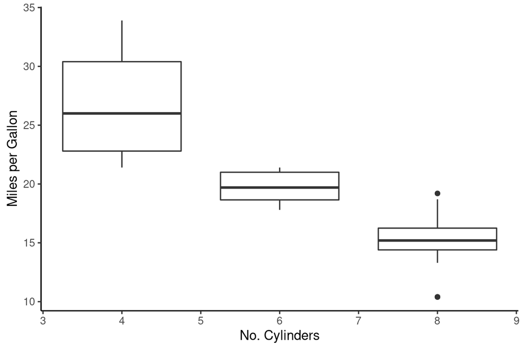

```r
ggplot(mtcars, aes(cyl, mpg, group = cyl)) +
  geom_boxplot() +
  labs(x = "No. Cylinders", y = "Miles per Gallon") +
  theme_classic()
```

For the plot, we can use the options to change the height, width, and alignment of our output plot. Again, refer to the [cheatsheet](https://rstudio.com/wp-content/uploads/2015/02/rmarkdown-cheatsheet.pdf) for more options.

Code chunk options can be set globally at the beginning of the document, like `knitr::opts_chunk$set(echo = TRUE)`, or for specific chunks.  
If you wish to specify multiple code chunk options, they are separated with a comma.

## Inserting images and links

To create a link, use the following syntax: `[text to click on](link)`. This create something like [this](https://rstudio.com/wp-content/uploads/2015/02/rmarkdown-cheatsheet.pdf).  
For images, we use a slight variant of the above: `![optional caption](path/to/image.png).` R will look for the image in the same directory as the Rmd file, and display it in the document, like the example near the start of this lesson. Another example image is included below, with the sytax `![](drawing.png)`.

[figure not shown]

## Other YAML options

Here is another example of another YAML header, this one including a few more modifications:

```r
---
title: "Title"
author: "Travis Blimkie"
date: "`r format(Sys.time(), '%B %d, %Y')`"
output:
  html_document:
    theme: flatly
    highlight: kate
    code_folding: show
    toc: yes
---
```

A breakdown of these options:

- The date field is set to some R code, which grabs the current date and formats it as “Month Date, Year”
- Set the theme for the document (not code chunks), see a list of available options [here](https://bookdown.org/yihui/rmarkdown/html-document.html#appearance-and-style)
- Syntax highlight style for code chunks, available options [here](https://bookdown.org/yihui/rmarkdown/html-document.html#appearance-and-style)
- Enable hiding of code, but default to showing code
- Enable click-able table of contents

## Other output options

In addition to rendering your Rmd as an HTML file, you can use other options including:

- github_document
- pdf_document (may need to install additional packages)
- io_slides for presentation